# Tutorial 4 - Inflation, unemployment, and interest rates - Solutions

Theo Arvanitopoulos

# Exercises

## Exercise 1

Below are some data from the country of Readingland, which produces only two commodities, beer and pizza. Let 2016 be the base year.

| Year | Price of beer | Quantity of beer | Price of pizza£ | Quantity of pizza |
| --- | --- | --- | --- | --- |
| 2016 | £1 | 100 | £2 | 50 |
| 2017 | £1 | 200 | £2 | 100 |
| 2018 | £2 | 200 | £4 | 100 |

a. Calculate the CPI for 2017 and for 2018.

b. What was the annual inflation between 2017 and 2018?

**Answer:**

Keep the 2016 quantities fixed: 100 units of beer and 50 units of pizza. The basket costs £200 in 2016, £200 in 2017, and £400 in 2018.

a. With the base-year index equal to 100:

$$CPI_t=\frac{\text{cost of the 2016
basket at year }t\text{ prices}}{\text{cost of the 2016 basket at 2016
prices}}\times100.$$

$$CPI_{2017}=\frac{200}{200}\times100=100,\qquad
CPI_{2018}=\frac{400}{200}\times100=200.$$

b. Inflation is the percentage change in the index, not the index level:

$$\pi_{2018}=\frac{CPI_{2018}-CPI_{2017}}{CPI_{2017}}\times100=\frac{200-100}{100}\times100=100\%.$$

## Exercise 2

You found a great deal on a dream computer and need to borrow £1,500 from your parents to buy it. They insist that this is your investment and expect you to pay £1,650 back at the end of the year. You sign an IOU, and everyone expects the rate of inflation to be 5%. Finally, suppose everyone also assumes the Fisher equation to be true.

a. If, at the end of the year, you find that you were correct and the annual inflation rate was 5%, will your repayment, in real terms, be different from what you and your parents expected? What is the real interest rate that you will pay?

b. If, instead, the annual inflation rate was 10%, who benefited from this unexpectedly high rate of inflation? What was the actual real interest rate that you pay in this case?

**Answer:**

The nominal interest rate is $i=(1{,}650-1{,}500)/1{,}500=0.10$, or 10%. Expected inflation at the time of the loan is $\pi^e=0.05$. Use decimals in the exact Fisher relationship:

$$r=\frac{1+i}{1+\pi}-1,\qquad r\approx
i-\pi.$$

a. If actual inflation is $\pi=0.05$, it matches expectations. The realised real return equals the expected real return:

$$r=\frac{1.10}{1.05}-1\approx0.04762=4.76\%.$$

The approximate calculation gives $10\%-5\%=5\%$. The £1,650 repayment has purchasing power of $\text{£}1{,}650/1.05\approx\text{£}1{,}571.43$ in prices at the start of the loan, as expected.

b. If actual inflation is $\pi=0.10$, while expected inflation remains $\pi^e=0.05$:

$$r=\frac{1.10}{1.10}-1=0.$$

The borrower benefits relative to the agreed loan’s expected real cost; the parents receive a lower real return than expected. The repayment is worth $\text{£}1{,}650/1.10=\text{£}1{,}500$ in starting-year prices. Its nominal amount remains £1,650.

## Exercise 3

Consider an economy where of all adult people, 27.6 million are employed, 1.5 million are unemployed, and 17.1 million are not in the labour force.

a. How big is the labour force?

b. What is the labour force participation rate?

c. What is the unemployment rate?

**Answer:**

Let $E$ be employment, $U$ unemployment, $LF$ the labour force, and $N$ the adult population. All counts are in millions.

a. $LF=E+U=27.6+1.5=29.1$ million.

b. $N=27.6+1.5+17.1=46.2$ million. Thus

$$LFPR=\frac{LF}{N}\times100=\frac{29.1}{46.2}\times100\approx62.99\%.$$

c. Use the labour force, not the adult population, as the unemployment-rate denominator:

$$UR=\frac{U}{LF}\times100=\frac{1.5}{29.1}\times100\approx5.15\%.$$

## Exercise 4

Consider a simple closed economy with only three goods: computers, flour and pasta. Note that:

A) Half the flour production is sold to the pasta maker and half is sold to consumers who make their own bread.

B) The government provides an annual subsidy of £80 to the flour industry.

C) The wheat grinder (used to make flour) depreciates a total of £50 during the year.

The following table provides information on prices and output in two *consecutive* years:

| Product | Base-year price ($P_{i0}$) | Base-year quantity ($Q_{i0}$) | Current price ($P_{i1}$) | Current quantity ($Q_{i1}$) |
| --- | --- | --- | --- | --- |
| Computers | £100.00 | 50 | £90.00 | 100 |
| Flour | £1.00 | 1,000 | £1.00 | 1,200 |
| Pasta | £5.00 | 100 | £6.00 | 150 |

Incomes in the current year are:

| Recipient |  | Type of Income |  | Amount |
| --- | --- | --- | --- | --- |
| *Computers* |  |  |  |  |
| factory owners |  | rent for factory |  | £500 |
| workers |  | wages |  | £6,000 |
| owner of company |  | profit |  | £2,500 |
| *Flour* |  |  |  |  |
| farm and mill workers |  | wages |  | £900 |
| owner of grinder |  | rent for machinery |  | £100 |
| owners of company |  | profit |  | £255 |
| *Pasta* |  |  |  |  |
| owner owns pasta cutter |  | imputed rent for machinery |  | £75 |
| owner-operator |  | proprietor’s income |  | £200 |

a. Calculate nominal GDP in the current year using both the expenditure approach and the income approach.

b. What is real GDP in the current year?

c. Did the economy grow (in real terms) between the two years? If so, how much?

d. What is the CPI in the current year if the basket of goods includes only the base year consumption levels of pasta and computers. What happened to average prices?

e. What is the GDP deflator in the current year? How does this compare to the CPI from part d?

**Answer:**

Use 0 for the base year and 1 for the current year. $P_{it}$ and $Q_{it}$ denote the price and quantity of good $i$ in year $t$. All price indices below use base year = 100.

a. Expenditure approach: include computers, pasta, and only the flour sold directly to consumers. The other half of the flour is an intermediate input.

$$GDP_1^{\mathrm{nominal}}=90(100)+1(600)+6(150)=10{,}500.$$

Income approach: wages $6{,}900$, corporate profits $2{,}755$, rental income $675$, and proprietor’s income $200$ sum to $10{,}530$. Deduct the subsidy of $80$ and add depreciation of $50$:

$$GDP_1^{\mathrm{nominal}}=10{,}530-80+50=10{,}500.$$

b. At base-year prices:

$$GDP_1^{\mathrm{real}}=100(100)+1(600)+5(150)=11{,}350.$$

c. Base-year real GDP is $100(50)+1(500)+5(100)=6{,}000$. Real growth is

$$\frac{11{,}350-6{,}000}{6{,}000}\times100\approx89.17\%.$$

d. Use the fixed base-year basket of 50 computers and 100 units of pasta:

$$CPI_1=\frac{90(50)+6(100)}{100(50)+5(100)}\times100\approx92.73.$$

The basket costs about 7.27% less than in the base year.

e. The GDP deflator is

$$\text{GDP
deflator}_1=\frac{10{,}500}{11{,}350}\times100\approx92.51.$$

Domestic final-output prices are about 7.49% lower on this measure. The indices differ because the CPI uses the specified fixed consumer basket, whereas the deflator uses current domestic final-output quantities and includes final flour.

## Exercise 5

Using a graph, show how an increase in the minimum wage would affect the labour market.

**Answer:**

Draw labour demand sloping down and labour supply sloping up, with the real wage on the vertical axis and labour on the horizontal axis. Mark the market-clearing wage. In this competitive-market diagram, assume the new minimum wage is binding and above that wage. At the higher wage floor, labour supplied exceeds labour demanded; their horizontal distance is excess labour supply. If the minimum wage remains below the market-clearing wage, it is non-binding and has no effect in this model. The prediction depends on the competitive-market assumptions.

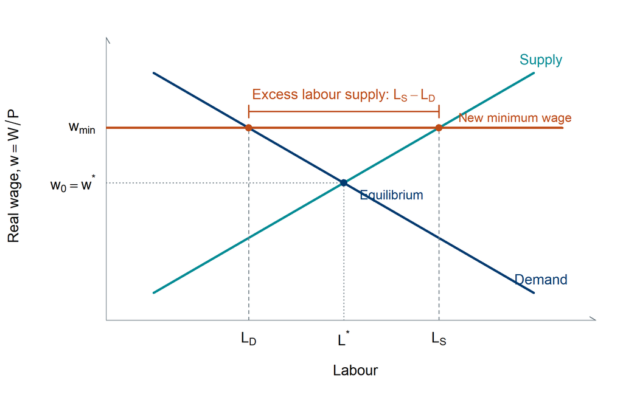

The higher wage floor reduces employment demanded to $L_D$ and raises labour supplied to $L_S$. The gap $L_S-L_D$ is excess labour supply in this competitive model; the initial wage floor $w_0$ is shown at equilibrium.

## Exercise 6

Suppose it was the case that between the end of 2015 and end of 2018, total UK employment increased by almost exactly 1 million workers. At the same time, the number of unemployed workers declined by only about 70,000. How do you think this is possible?

**Answer:**

It must be the case that the labour force increased between 2015 and 2018. This could be due to either an increase in the adult population (general population growth plus net migration), or an increase in the labour force participation rate, or both.

# Multiple-choice questions

## MCQ 1

Suppose that the nominal wage rate is £5 per hour and that the price level is 100. If the nominal wage rate falls to £2.50 per hour and the price level falls to 50, what happens to the real wage?

a. the real wage doubles

b. the real wage rises but does not double

c. the real wage rate does not change

d. the real wage rate falls

**Answer:**

C

## MCQ 2

The natural rate of unemployment is the unemployment rate when there is no

a. cyclical unemployment.

b. structural or cyclical unemployment.

c. frictional or seasonal unemployment.

d. frictional or structural unemployment.

**Answer:**

A

## MCQ 3

In the simple job-search model, the time spent by unemployed people searching for jobs

a. falls if unemployment compensation becomes more generous and if the coverage of unemployment insurance increases

b. falls if unemployment compensation becomes more generous and if the coverage of unemployment insurance decreases

c. rises if unemployment compensation becomes more generous and if the coverage of unemployment insurance decreases

d. rises if unemployment compensation becomes more generous and if the coverage of unemployment insurance increases

**Answer:**

D. In the simple job-search mechanism, more generous benefits and broader coverage can allow longer search. This is a model prediction rather than a universal empirical claim.

## MCQ 4

Assume price-taking firms, diminishing marginal product of labour, and unchanged productivity and capital, so the labour-demand schedule is fixed. If the price level rises by 5 percent and nominal wages remain constant, the aggregate

a. quantity of labour demanded will decrease

b. quantity of labour demanded will increase

c. demand for labour will decrease

d. demand for labour will increase

**Answer:**

B